# GVPT 2020 Fall Method Workshop: Modelling

November 17, 2020

## 2020 GVPT Method WorKshop

– **Manage work flows**

– **Data collection**

– **Data cleaning**

– **Learn from your data (today)**

– **Visualization: communicate to others (next workshop)**

## What Is Not Covered in This Presentation

– **Causal inference (next semester)**

– **Basics and extensions of models (GVPT 622, 722, 729, …)**

– **Integrating theoretical and empirical models (EITM)**

– **Machine learning**

## What This Presentation Is About

– **How Models Can Benefit and Mislead Us**

- Data generating process
- Data versus model structure
- Use intuitive examples to highlight practical trade-offs

– **Use Modelling Tools from *Tidyverse* Package**

- Tools that make data exploratory easier (know your data)
- Work with pipes and seamlessly connect with data
- *R for Data Science*, https://r4ds.had.co.nz/

## Data Generating Process

Let's say we have the following dataset

```
## # A tibble: 500 x 3
##           y     D      X
##       <dbl> <dbl>  <dbl>
##  1   2.23       0  3.37
##  2   8.24       0  2.66
##  3  -0.0692     0 -0.329
##  4  -4.02       1 -4.03
##  5   3.37       0  1.82
##  6   4.60       1  1.83
##  7  -6.00       1 -1.97
##  8  -1.60       1  2.54
##  9   9.39       1  4.31
## 10 -16.2        0 -2.54
## # ... with 490 more rows
```

## Data Generating Process

– How are y, D, and X generated?

– What distributions do y, D, and X come from?

– Are observations correlated and how?

– Are variables correlated and how?

……

**We often don't know the true data generating process**

## Model

– **Models partition variations into patterns and noises**

- Variation: within a variable
- Covariation: between variables
- A model is a low-dimension summary of the dataset

– **Models are subjective**

- "All models are wrong, but some are useful"
- "A model is a representation for a particular purpose"

## Model and Data

– **Models put structures on data**

- Assumptions about connections among variables are made
- Functional forms

\[y=\alpha_0+\alpha_1 x_1+ \alpha_2 x_2 +\alpha_3 x_3\]

## Model and Data

– **Why not just let data speak for itself**

- There are ways to extract connections without structures
- But structures may exist in the data
- Easier to interpret
- Easier to quantify uncertainty
- We have theories (know the data generating process)

– **We do not always have the luxury to let data speak for itself**

- **We need large and informative data!**
- **Research designs!** (next semester)

## Example 1

```r
library(tidyverse)
### Set the seed of R's random number generator (for reproducibility)
set.seed(1221)
### Number of observations
obs<-500
### Generate D
D<-sample(c(0,1),obs,replace=T)
### Generate X
mu_x<-1; sigma_x<-5
X<-rnorm(n=obs,mean=mu_x,sd=sigma_x)
### Generate Y (Y=b0+b1*D+b2*X+e)
b0<-0.5; b1<-1.6; b2<-1.8; mu_e<-0; sigma_e<-5
y<-b0+b1*D+b2*X+rnorm(n=obs,mean=mu_e,sd=sigma_e)
```

**What does this data generating process tell us?**

## Example 1

```r
### tibble y, D, and X as a dataset
d<-tibble(y,D,X)
### take a look at the data
summary(d)
```

```
##        y                 D              X
##  Min.   :-22.632   Min.   :0.00   Min.   :-14.8538
##  1st Qu.: -2.759   1st Qu.:0.00   1st Qu.: -2.0239
##  Median :  3.045   Median :0.00   Median :  1.1635
##  Mean   :  3.288   Mean   :0.48   Mean   :  0.9962
##  3rd Qu.:  9.128   3rd Qu.:1.00   3rd Qu.:  4.2281
##  Max.   : 26.972   Max.   :1.00   Max.   : 13.0630
```

## Example 1

**Research question: how does D affect Y?**

```r
### compare two group means: Student-t test
t.test(y~D,var.equal=T)
```

```
##
##  Two Sample t-test
##
## data:  y by D
## t = -2.934, df = 498, p-value = 0.003501
## alternative hypothesis: true difference in means is not equal to 0
## 95 percent confidence interval:
##  -3.9479901 -0.7811449
## sample estimates:
## mean in group 0 mean in group 1
##        2.152620        4.517187
```

## Example 1

```r
### compare two group means (an equivalent way but using "lm")
gpmeans<-lm(data=d,y~D);summary(gpmeans)$coefficients
```

```
##             Estimate Std. Error  t value    Pr(>|t|)
## (Intercept) 2.152620  0.5583578 3.855269 0.000130749
## D           2.364567  0.8059201 2.933997 0.003500633
```

```r
### adding x2, assuming a linear relationship y=beta0+beta1*D+beta2*X
mod<-lm(data=d,y~D+X);summary(mod)$coefficients
```

```
##              Estimate Std. Error   t value      Pr(>|t|)
## (Intercept) 0.6905612 0.28875848  2.391484  1.715130e-02
## D           1.8630273 0.41317014  4.509104  8.129482e-06
## X           1.7092072 0.04568437 37.413394 1.195589e-146
```

## Example 1

**Bias** (repeated sampling)

```r
### a function to generate data
func_dgp<-function(N,mu_x,sigma_x,mu_e,sigma_e,b0,b1,b2){
  tibble(D=sample(c(0,1),N,replace=T),
         X=rnorm(N,mu_x,sigma_x),
         y=b0+b1*D+b2*X+rnorm(N,mu_e,sigma_e))
}
### a function to compare two group means
func_gpmeans<-function(dataset){
  m<-lm(data=dataset,y~D);coef(m)[2]
}
### a function to add X as a linear model
func_lmod<-function(dataset){
  m<-lm(data=dataset,y~D+X);coef(m)[2]
}
```

## Example 1

**Bias** (repeated sampling)

```r
### repeated sampling and sampling distribution
ndraws<-1000
est_gpmeans<-est_lmod<-list()
for (i in 1:ndraws){
  # draw 1000 samples
  d_repeated<-func_dgp(N=obs,mu_x=mu_x,mu_e=mu_e,
                       sigma_x=sigma_x,sigma_e=sigma_e,
                       b0=b0,b1=b1,b2=b2)
  # for each sample, compare the two group means
  est_gpmeans[[i]]<-func_gpmeans(data=d_repeated)
  # for each sample, run a linear model y~D+X
  est_lmod[[i]]<-func_lmod(data=d_repeated)
}
### tibble the sampling distributions
est_sampling<-tibble(est_1=unlist(est_gpmeans),est_2=unlist(est_lmod))
```

## Example 1

**Bias** (repeated sampling)

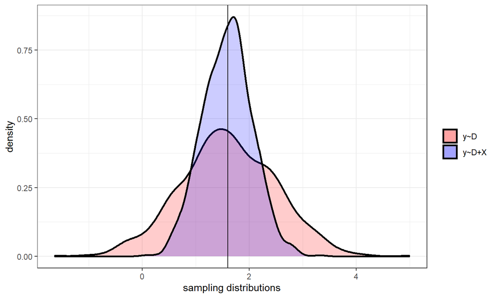

## Example 1

**Consistency** (number of observations grows to infinity)

```r
sample_size<-seq(from=500,to=50000,by=100)
est_gpmeans<-est_lmod<-list()
for (i in 1:length(sample_size)){
  # draw samples with different sample_size
  d_asymptotic<-func_dgp(N=sample_size[i],mu_x=mu_x,mu_e=mu_e,
                       sigma_x=sigma_x,sigma_e=sigma_e,
                       b0=b0,b1=b1,b2=b2)
  # for each sample, compare the two group means
  est_gpmeans[[i]]<-func_gpmeans(data=d_asymptotic)
  # for each sample, run a linear model y~D+X
  est_lmod[[i]]<-func_lmod(data=d_asymptotic)
}
### tibble the sampling distributions
est_asymptotic<-tibble(est_1=unlist(est_gpmeans),
                       est_2=unlist(est_lmod))
```

## Example 1

**Consistency** (number of observations grows to infinity)

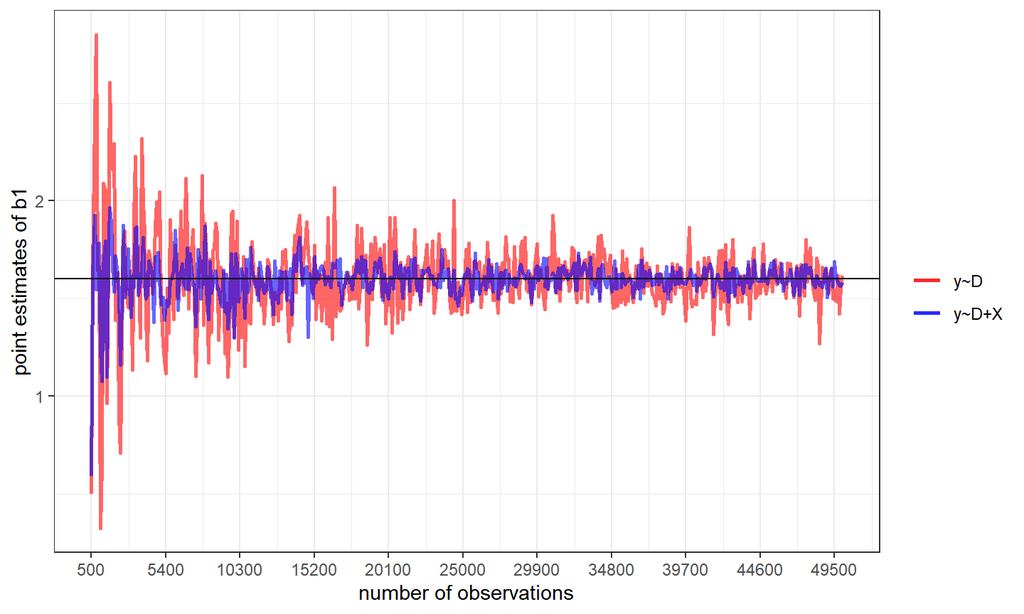

## Take-away Points from Example 1

**In a randomized experiment (or a very good research design)**

– Modelling is not essential in estimating the treatment effect

– Correctly specified models reduce standard errors

– Sample size matters

– With samller sampe sizes, correct model helps

## Example 2

```r
set.seed(1221)
### Number of observations
obs<-500
### Generate age
Age<-round(runif(n=obs,min=18,max=50))
### Generate gender
Gender<-sample(c(0,1),obs,replace=T)
### Generate D
xb<-(-9.5)+0.6*Age-0.01*I(Age^2)+2.8*Gender
p<-exp(xb)/(1+exp(xb))
D<-rbinom(n=obs,size=1,prob=p)
### Generate Y (Y=b0+b1*D+b2*Age+b3*Age^2+b4*Gender+e)
b0<-0.5; b1<-1.6; b2<-3.5; b3<-(-0.1); b4<-1.2
y<-b0+b1*D+b2*Age+b3*I(Age^2)+b4*Gender+
  rnorm(n=obs,mean=mu_e,sd=sigma_e)
```

**What does this data generating process tell us?**

## Example 2

```r
### tibble y, D, and X as a dataset
d<-tibble(y,D,Age,Gender)
### take a look at the data
summary(d)
```

```
##        y                 D              Age            Gender
##  Min.   :-83.698   Min.   :0.000   Min.   :18.00   Min.   :0.000
##  1st Qu.:-31.212   1st Qu.:0.000   1st Qu.:26.00   1st Qu.:0.000
##  Median :  8.709   Median :0.000   Median :33.00   Median :0.000
##  Mean   : -3.341   Mean   :0.496   Mean   :33.94   Mean   :0.494
##  3rd Qu.: 25.249   3rd Qu.:1.000   3rd Qu.:42.00   3rd Qu.:1.000
##  Max.   : 41.760   Max.   :1.000   Max.   :50.00   Max.   :1.000
```

## Example 2

```r
### compare two group means
gpmeans<-lm(data=d,y~D)
summary(gpmeans)$coefficients
```

```
##              Estimate Std. Error   t value     Pr(>|t|)
## (Intercept) -15.35708   1.958608 -7.840810 2.741214e-14
## D            24.22629   2.781037  8.711242 4.461578e-17
```

This is way off and we "know" why.

## Example 2

**Control covariates by putting structures on data: modelling**

\[y=\alpha_0+\alpha_1 D + \alpha_2 Age +\alpha_3 Gender\]

– The effect of \(D\) while holding \(Age\) and \(Gender\) equal

– The assumption: this is the correct functional form

## Example 2

```r
### modelling with the above functional form
mod<-lm(data=d,y~D+Age+Gender)
summary(mod)$coefficients
```

```
##               Estimate Std. Error    t value      Pr(>|t|)
## (Intercept) 104.185216 1.72579855  60.369280 1.079531e-230
## D             7.071475 1.03435959   6.836573  2.390909e-11
## Age          -3.252947 0.04471686 -72.745418 8.864893e-267
## Gender       -1.272248 0.99311489  -1.281068  2.007683e-01
```

## Example 2

```r
### modelling with the correct functional form
mod_true<-lm(data=d,y~D+Age+I(Age^2)+Gender)
summary(mod_true)$coefficients
```

```
##               Estimate  Std. Error    t value      Pr(>|t|)
## (Intercept) -3.3402132 3.006928258  -1.110839  2.671769e-01
## D            1.7874832 0.547790908   3.263076  1.178250e-03
## Age          3.7315802 0.188105033  19.837748  7.044637e-65
## I(Age^2)    -0.1030266 0.002754076 -37.408779 2.288069e-146
## Gender       0.9451910 0.511607964   1.847491  6.527250e-02
```

We often don't know this

## Example 2

**An intuitive way to control covariates: stratification**

–**compare cases in two groups with the same gender**

-[D=1, Gender=1], [D=0, Gender=1]

-[D=1, Gender=0], [D=0, Gender=0]

–**compare cases in two groups with the same gender and age**

-[D=1, Gender=1, Age=25], [D=0, Gender=1, Age=25]

-[D=1, Gender=0, Age=26], [D=0, Gender=0, Age=26]

## Example 2

– **Problems with continuous variables**

-[D=1, Gender=1, Age=[20,30)],[D=0, Gender=1, Age=[20,30)]

-[D=1, Gender=0, Age=[30,40)],[D=0, Gender=0, Age=[30,40)]

– **How to stratify continuous variables**

-many continuous variables have "natural" breakpoints

-years of education (high school, college, graduate)

-income (official poverty level)

-assumptions: variations between strata and within strata

## Example 2

**This is the idea of matching**

– Matching as data preprossing to reduce model dependence

Ho, Daniel E., Kosuke Imai, Gary King, and Elizabeth A. Stuart. "Matching as nonparametric preprocessing for reducing model dependence in parametric causal inference." Political analysis 15, no. 3 (2007): 199-236.

– Losses of data and efficiency

– How to quantify uncertainty

Iacus, Stefano M., Gary King, and Giuseppe Porro. "A theory of statistical inference for matching methods in causal research." Political Analysis 27, no. 1 (2019): 46-68.

## Example 2

**Common support and extrapolation**

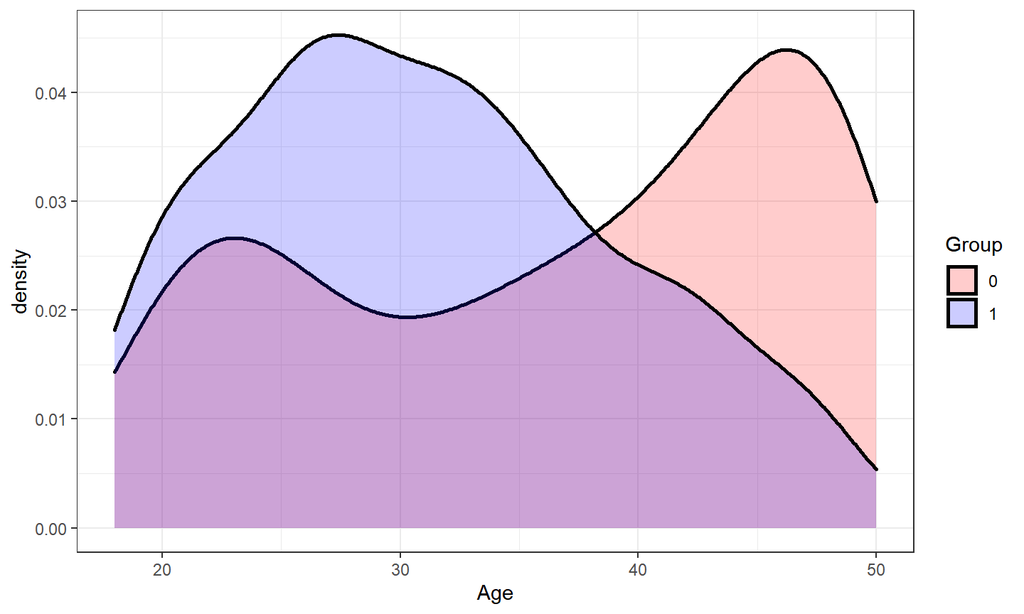

## Example 2

**Common support and extrapolation**

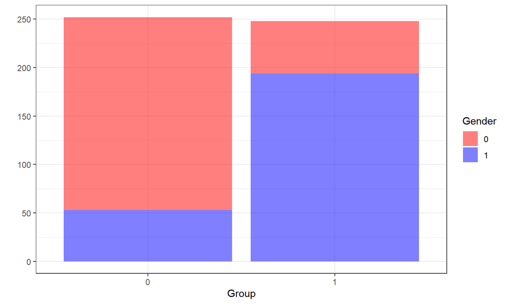

## Example 2

```r
### Require the MatchIt package
library(MatchIt)
### Discard data that cannot be matched within strata
mat<-matchit(D~Age+Gender,data=d,method="cem")
```

```
##
## Using 'treat'='1' as baseline group
```

```r
mat$nn
```

```
##           Control Treated
## All           252     248
## Matched       213     248
## Unmatched      39       0
## Discarded       0       0
```

## Example 2

```r
### The new dataset
d_mat<-tibble(get_matches(mat,d));d_mat
```

```
## # A tibble: 461 x 5
##           y     D   Age Gender weight
##    <I<dbl>> <int> <dbl>  <dbl>  <dbl>
##  1    22.4      1    26      1 1
##  2    32.9      0    21      0 0.354
##  3    24.9      1    27      1 1
##  4   -25.0      1    42      1 1
##  5     6.69     0    33      0 0.455
##  6   -43.7      0    44      0 0.0286
##  7   -73.8      0    50      1 0.477
##  8    10.8      1    28      1 1
##  9    -5.28     1    37      1 1
## 10   -37.5      0    42      0 0.129
## # ... with 451 more rows
```

## Example 2

```r
### compare group means within each strata and aggregate (weights)
gpmeans_strata<-lm(data=d_mat,y~D, weights = weight);
summary(gpmeans_strata)$coefficients
```

```
##             Estimate Std. Error  t value     Pr(>|t|)
## (Intercept) 6.966960   1.738083 4.008417 7.132257e-05
## D           1.902251   2.369709 0.802736 4.225428e-01
```

## Example 2

```r
### modelling with the wrong functional form
mod_false<-lm(data=d_mat,y~D+Age+Gender,weights = weight);
summary(mod_false)$coefficients
```

```
##               Estimate Std. Error    t value      Pr(>|t|)
## (Intercept) 100.583468 1.70962083  58.833787 2.310359e-215
## D             1.661565 0.77580599   2.141728  3.274345e-02
## Age          -2.969461 0.04836061 -61.402469 6.804206e-223
## Gender       -1.047795 0.94211789  -1.112170  2.666497e-01
```

## Example 2

```r
### modelling with the right functional form
mod_true<-lm(data=d_mat,y~D+Age+I(Age^2)+Gender,weights = weight);
summary(mod_true)$coefficients
```

```
##               Estimate  Std. Error     t value      Pr(>|t|)
## (Intercept) -2.8883926 3.062346524  -0.9431959  3.460802e-01
## D            1.4128727 0.402075305   3.5139503  4.855646e-04
## Age          3.7419579 0.191781902  19.5115279  4.367112e-62
## I(Age^2)    -0.1031897 0.002923413 -35.2976970 1.694439e-132
## Gender       0.6487989 0.490554882   1.3225817  1.866375e-01
```

## Example 2

**Matching estimators using satuated regressions**

Angrist, Joshua D., and Jörn-Steffen Pischke. Mostly harmless econometrics: An empiricist's companion. Princeton university press, 2008.

– Putting each strata as a dummy

– No functional forms are assumed

– A matching estimator with different weights

```r
### cut Age to 9 groups with equal size
d<-d %>% mutate(Age_strata=cut_number(Age,n=9))
### Gender, Age_strata and their interactions
mod_mat<-lm(data=d,y~D+Gender*Age_strata)
```

```
##                               Estimate Std. Error
## (Intercept)                 29.5224252  0.9997324
## D                            2.0592773  0.6959471
## Gender                       1.2062683  1.3841295
## Age_strata(22,25]           -3.2608293  1.4555936
## Age_strata(25,28]           -6.7499193  1.6518048
## Age_strata(28,32]          -14.3060497  1.5575894
## Age_strata(32,35]          -24.2009735  1.5013011
## Age_strata(35,39.7]        -36.1244615  1.4696377
## Age_strata(39.7,43]        -55.6841873  1.4748829
## Age_strata(43,47]          -76.5754924  1.4287087
## Age_strata(47,50]          -95.5409740  1.4204115
## Gender:Age_strata(22,25]    -0.1259973  2.2510977
## Gender:Age_strata(25,28]    -2.0065039  2.1258564
## Gender:Age_strata(28,32]    -0.4361076  2.0553695
## Gender:Age_strata(32,35]    -0.2513895  2.1859322
## Gender:Age_strata(35,39.7]  -2.6475749  2.0717133
## Gender:Age_strata(39.7,43]  -3.4754404  2.0245653
## Gender:Age_strata(43,47]    -1.6928610  2.0480419
## Gender:Age_strata(47,50]     0.4231881  2.1693681
```

## Take-away Points from Example 2

**In non-experimental studies, we face trade-offs**

– Modelling helps partion the effect of interests

- If the functional form is correctly specified
- But we need to know the functional forms

– There are ways to partion the effect of interest without modelling

- not model dependent (do not need to assume functional forms)
- The curse of dimensionality
- losses of data and efficiency (structures of the data are not used)
- how to quantify uncertainty

## Take-away Points from Example 2

**How to deal with the trade-offs**

– Nonparametric data preprocessing before modelling

– Present results of both

– **Data collection: large and informative data**

An example: Chen, Ting, and James Kai-sing Kung. "Busting the “Princelings”: The campaign against corruption in China’s primary land market." The Quarterly Journal of Economics 134, no. 1 (2019): 185-226.

– **Research design** (next semester)

## Modelling with Pipes

**Tools that make data exploratory easier (Know your data)**

*Modelr, Purrr, and Broom*

– *Modelr*: integrating modelling and data with pipes

– *purrr* and *broom*: seamlessly connect data with many models

## *Modelr*

```r
library(tidyverse);library(modelr)
### read the dataset: media freedom, country-year
d_media<-read_csv("media.csv");d_media
```

```
## # A tibble: 3,145 x 7
##     year country media_score media_status population gdp_percapita
##    <dbl> <chr>         <dbl> <chr>             <dbl>         <dbl>
##  1  1993 United~          88 F             259919000        26465.
##  2  1994 United~          88 F             263126000        27777.
##  3  1995 United~          86 F             266278000        28782.
##  4  1996 United~          86 F             269394000        30068.
##  5  1997 United~          88 F             272657000        31573.
##  6  1998 United~          87 F             275854000        32949.
##  7  1999 United~          87 F             279040000        34621.
##  8  2000 United~          85 F             282162411        36450.
##  9  2001 United~          84 F             284968955        37274.
## 10  2002 United~          83 F             287625193        38166.
## # ... with 3,135 more rows, and 1 more variable: gdp_growth <dbl>
```

## *Modelr*

```r
### model matrix
model_matrix(d_media,media_score~gdp_percapita)
```

```
## # A tibble: 3,145 x 2
##    `(Intercept)` gdp_percapita
##            <dbl>         <dbl>
##  1             1        26465.
##  2             1        27777.
##  3             1        28782.
##  4             1        30068.
##  5             1        31573.
##  6             1        32949.
##  7             1        34621.
##  8             1        36450.
##  9             1        37274.
## 10             1        38166.
## # ... with 3,135 more rows
```

## *Modelr*

```r
### model matrix
model_matrix(d_media,media_score~log(gdp_percapita))
```

```
## # A tibble: 3,145 x 2
##    `(Intercept)` `log(gdp_percapita)`
##            <dbl>                <dbl>
##  1             1                 10.2
##  2             1                 10.2
##  3             1                 10.3
##  4             1                 10.3
##  5             1                 10.4
##  6             1                 10.4
##  7             1                 10.5
##  8             1                 10.5
##  9             1                 10.5
## 10             1                 10.5
## # ... with 3,135 more rows
```

## *Modelr*

```r
### other transformations
# I (): e.g. I (x^2)
# poly (): polynomial
# ns (): natural splines from "splines" package
```

## *Modelr*

```r
### a simple model
mod_1<-lm(data=d_media,media_score~log(gdp_percapita))
### add predictions to the existing dataset
d_media<-d_media %>% add_predictions(mod_1)
### add residuals to the existing dataset
d_media<-d_media %>% add_residuals(mod_1)
### the basic R function predict() returns a vector
```

## *Modelr*

```r
d_media
```

```
## # A tibble: 3,145 x 9
##     year country media_score media_status population gdp_percapita
##    <dbl> <chr>         <dbl> <chr>             <dbl>         <dbl>
##  1  1993 United~          88 F             259919000        26465.
##  2  1994 United~          88 F             263126000        27777.
##  3  1995 United~          86 F             266278000        28782.
##  4  1996 United~          86 F             269394000        30068.
##  5  1997 United~          88 F             272657000        31573.
##  6  1998 United~          87 F             275854000        32949.
##  7  1999 United~          87 F             279040000        34621.
##  8  2000 United~          85 F             282162411        36450.
##  9  2001 United~          84 F             284968955        37274.
## 10  2002 United~          83 F             287625193        38166.
## # ... with 3,135 more rows, and 3 more variables: gdp_growth <dbl>,
## #   pred <dbl>, resid <dbl>
```

## *Modelr*

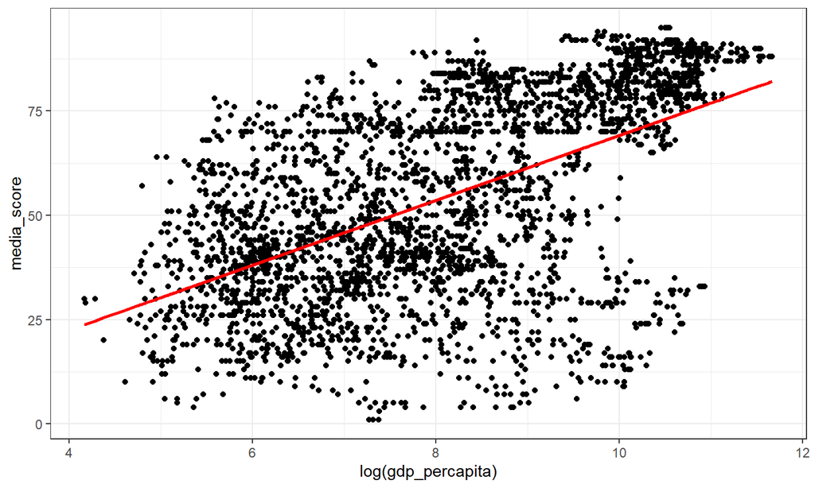

```r
### it's easy to work with
ggplot(d_media,aes(x=log(gdp_percapita)))+
  geom_point(aes(y=media_score))+
  geom_line(aes(y=pred),lwd=1,colour="red")+
  theme_bw()
```

## *Modelr*

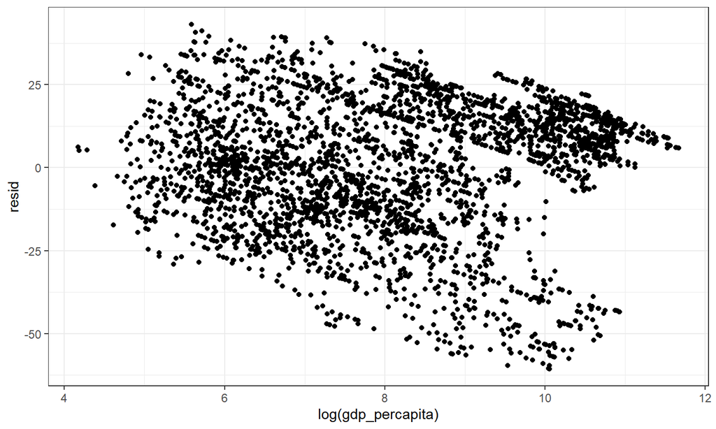

```r
### it's easy to work with
ggplot(d_media,aes(x=log(gdp_percapita)))+
  geom_point(aes(y=resid))+
  theme_bw()
```

## *Modelr*

```r
### model matrix: adding another predictor
model_matrix(d_media,media_score~log(gdp_percapita)+log(population))
```

```
## # A tibble: 3,145 x 3
##    `(Intercept)` `log(gdp_percapita)` `log(population)`
##            <dbl>                <dbl>             <dbl>
##  1             1                 10.2              19.4
##  2             1                 10.2              19.4
##  3             1                 10.3              19.4
##  4             1                 10.3              19.4
##  5             1                 10.4              19.4
##  6             1                 10.4              19.4
##  7             1                 10.5              19.4
##  8             1                 10.5              19.5
##  9             1                 10.5              19.5
## 10             1                 10.5              19.5
## # ... with 3,135 more rows
```

## *Modelr*

```r
### a model with both gdp per capita and population
mod_2<-lm(data=d_media,media_score~log(gdp_percapita)+log(population))
```

## *Modelr*

```r
### gather residuals/predictions on two (or multiple) models
d_media<-d_media %>% gather_residuals(mod_1,mod_2);d_media
```

```
## # A tibble: 6,290 x 10
##    model  year country media_score media_status population gdp_percapita
##    <chr> <dbl> <chr>         <dbl> <chr>             <dbl>         <dbl>
##  1 mod_1  1993 United~          88 F             259919000        26465.
##  2 mod_1  1994 United~          88 F             263126000        27777.
##  3 mod_1  1995 United~          86 F             266278000        28782.
##  4 mod_1  1996 United~          86 F             269394000        30068.
##  5 mod_1  1997 United~          88 F             272657000        31573.
##  6 mod_1  1998 United~          87 F             275854000        32949.
##  7 mod_1  1999 United~          87 F             279040000        34621.
##  8 mod_1  2000 United~          85 F             282162411        36450.
##  9 mod_1  2001 United~          84 F             284968955        37274.
## 10 mod_1  2002 United~          83 F             287625193        38166.
## # ... with 6,280 more rows, and 3 more variables: gdp_growth <dbl>,
## #   pred <dbl>, resid <dbl>
```

## *Modelr*

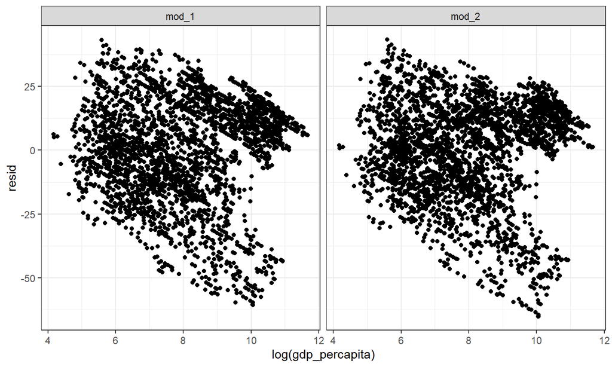

```r
ggplot(d_media,aes(x=log(gdp_percapita)))+
  geom_point(aes(y=resid))+
  facet_wrap(~model)+
  theme_bw()
```

## *Modelr*

```r
### use grid to customize input data
d_media %>%
  data_grid(gdp_percapita=seq_range(gdp_percapita,3),
            population=seq_range(population,2)) %>%
  spread_predictions(mod_1,mod_2)
```

```
## # A tibble: 6 x 4
##   gdp_percapita population mod_1 mod_2
##           <dbl>      <dbl> <dbl> <dbl>
## 1          64.8      41836  23.8  37.1
## 2          64.8 1371220000  23.8  13.0
## 3       58339.       41836  76.8  87.7
## 4       58339.  1371220000  76.8  63.5
## 5      116613.       41836  82.1  92.8
## 6      116613.  1371220000  82.1  68.7
```

## *Modelr*

```r
### use grid to hold other variables constant
d_media %>%
  data_grid(gdp_percapita=seq_range(gdp_percapita,n=6,trim=0.1),
            .model=mod_2) %>%
  add_predictions(mod_2)
```

```
## # A tibble: 6 x 3
##   gdp_percapita population  pred
##           <dbl>      <dbl> <dbl>
## 1          247.    8562623  34.7
## 2         9337.    8562623  61.7
## 3        18428.    8562623  66.8
## 4        27518.    8562623  69.7
## 5        36609.    8562623  71.9
## 6        45699.    8562623  73.5
```

## many models with *purrr* and *broom*

```r
library(purrr);library(broom)
### existing dataset: country-year; nest the existing data frame
d_media<-read_csv("media.csv")
d_media_byctry<-d_media %>%
  group_by(country) %>%
  nest()
```

## many models with *purrr* and *broom*

```r
d_media_byctry
```

```
## # A tibble: 137 x 2
## # Groups:   country [137]
##    country             data
##    <chr>               <list>
##  1 United States       <tibble [23 x 6]>
##  2 Canada              <tibble [23 x 6]>
##  3 Bahamas             <tibble [23 x 6]>
##  4 Dominican Republic  <tibble [23 x 6]>
##  5 Jamaica             <tibble [23 x 6]>
##  6 Trinidad and Tobago <tibble [23 x 6]>
##  7 Barbados            <tibble [23 x 6]>
##  8 Dominica            <tibble [23 x 6]>
##  9 Grenada             <tibble [23 x 6]>
## 10 Saint Lucia         <tibble [23 x 6]>
## # ... with 127 more rows
```

## many models with *purrr* and *broom*

```r
d_media_byctry$data[[1]]
```

```
## # A tibble: 23 x 6
##     year media_score media_status population gdp_percapita gdp_growth
##    <dbl>       <dbl> <chr>             <dbl>         <dbl>      <dbl>
##  1  1993          88 F             259919000        26465.     1.40
##  2  1994          88 F             263126000        27777.     2.77
##  3  1995          86 F             266278000        28782.     1.50
##  4  1996          86 F             269394000        30068.     2.60
##  5  1997          88 F             272657000        31573.     3.24
##  6  1998          87 F             275854000        32949.     3.24
##  7  1999          87 F             279040000        34621.     3.49
##  8  2000          85 F             282162411        36450.     2.94
##  9  2001          84 F             284968955        37274.    -0.0185
## 10  2002          83 F             287625193        38166.     0.846
## # ... with 13 more rows
```

## many models with *purrr* and *broom*

```r
### fit a model to each country and seamlessly connect with the data
# a function of regression
model_country<-function(df){
  lm(data=df,media_score~log(gdp_percapita))
}
# use map from purrr package to fit a model on each country
d_media_byctry<-d_media_byctry %>%
  mutate(model=map(data,model_country))
```

## many models with *purrr* and *broom*

```r
d_media_byctry
```

```
## # A tibble: 137 x 3
## # Groups:   country [137]
##    country             data              model
##    <chr>               <list>            <list>
##  1 United States       <tibble [23 x 6]> <lm>
##  2 Canada              <tibble [23 x 6]> <lm>
##  3 Bahamas             <tibble [23 x 6]> <lm>
##  4 Dominican Republic  <tibble [23 x 6]> <lm>
##  5 Jamaica             <tibble [23 x 6]> <lm>
##  6 Trinidad and Tobago <tibble [23 x 6]> <lm>
##  7 Barbados            <tibble [23 x 6]> <lm>
##  8 Dominica            <tibble [23 x 6]> <lm>
##  9 Grenada             <tibble [23 x 6]> <lm>
## 10 Saint Lucia         <tibble [23 x 6]> <lm>
## # ... with 127 more rows
```

## many models with *purrr* and *broom*

```r
### add residuals using map2
d_media_byctry<-d_media_byctry %>%
  mutate(resids=map2(data,model,add_residuals))
### the order of the argument matters here
# add_residuals(data, model, var = "resid")
```

## many models with *purrr* and *broom*

```r
d_media_byctry
```

```
## # A tibble: 137 x 4
## # Groups:   country [137]
##    country             data              model  resids
##    <chr>               <list>            <list> <list>
##  1 United States       <tibble [23 x 6]> <lm>   <tibble [23 x 7]>
##  2 Canada              <tibble [23 x 6]> <lm>   <tibble [23 x 7]>
##  3 Bahamas             <tibble [23 x 6]> <lm>   <tibble [23 x 7]>
##  4 Dominican Republic  <tibble [23 x 6]> <lm>   <tibble [23 x 7]>
##  5 Jamaica             <tibble [23 x 6]> <lm>   <tibble [23 x 7]>
##  6 Trinidad and Tobago <tibble [23 x 6]> <lm>   <tibble [23 x 7]>
##  7 Barbados            <tibble [23 x 6]> <lm>   <tibble [23 x 7]>
##  8 Dominica            <tibble [23 x 6]> <lm>   <tibble [23 x 7]>
##  9 Grenada             <tibble [23 x 6]> <lm>   <tibble [23 x 7]>
## 10 Saint Lucia         <tibble [23 x 6]> <lm>   <tibble [23 x 7]>
## # ... with 127 more rows
```

## many models with *purrr* and *broom*

```r
### use pmap: work with any number of arguments (as a list)
d_media_byctry %>% mutate(resids=pmap(list(data,model),add_residuals))
```

```
## # A tibble: 137 x 4
## # Groups:   country [137]
##    country             data              model  resids
##    <chr>               <list>            <list> <list>
##  1 United States       <tibble [23 x 6]> <lm>   <tibble [23 x 7]>
##  2 Canada              <tibble [23 x 6]> <lm>   <tibble [23 x 7]>
##  3 Bahamas             <tibble [23 x 6]> <lm>   <tibble [23 x 7]>
##  4 Dominican Republic  <tibble [23 x 6]> <lm>   <tibble [23 x 7]>
##  5 Jamaica             <tibble [23 x 6]> <lm>   <tibble [23 x 7]>
##  6 Trinidad and Tobago <tibble [23 x 6]> <lm>   <tibble [23 x 7]>
##  7 Barbados            <tibble [23 x 6]> <lm>   <tibble [23 x 7]>
##  8 Dominica            <tibble [23 x 6]> <lm>   <tibble [23 x 7]>
##  9 Grenada             <tibble [23 x 6]> <lm>   <tibble [23 x 7]>
## 10 Saint Lucia         <tibble [23 x 6]> <lm>   <tibble [23 x 7]>
## # ... with 127 more rows
```

## many models with *purrr* and *broom*

```r
### unnest residuals (for plotting or ...)
d_media_byctry %>% unnest(resids) %>% print(n=6)
```

```
## # A tibble: 3,145 x 10
## # Groups:   country [137]
##   country data  model  year media_score media_status population
##   <chr>   <lis> <lis> <dbl>       <dbl> <chr>             <dbl>
## 1 United~ <tib~ <lm>   1993          88 F             259919000
## 2 United~ <tib~ <lm>   1994          88 F             263126000
## 3 United~ <tib~ <lm>   1995          86 F             266278000
## 4 United~ <tib~ <lm>   1996          86 F             269394000
## 5 United~ <tib~ <lm>   1997          88 F             272657000
## 6 United~ <tib~ <lm>   1998          87 F             275854000
## # ... with 3,139 more rows, and 3 more variables: gdp_percapita <dbl>,
## #   gdp_growth <dbl>, resid <dbl>
```

## many models with *purrr* and *broom*

```r
### broom: turn model outputs into tidy data
tidy(mod_2)
```

```
## # A tibble: 3 x 5
##   term               estimate std.error statistic   p.value
##   <chr>                 <dbl>     <dbl>     <dbl>     <dbl>
## 1 (Intercept)           30.8      3.49       8.83 1.70e- 18
## 2 log(gdp_percapita)     7.43     0.209     35.5  9.71e-233
## 3 log(population)       -2.32     0.179    -13.0  1.68e- 37
```

```r
### also work with other hypothesis testing functions
# tt<-t.test(y~D)
# tidy(tt)
```

## many models with *purrr* and *broom*

```r
### broom: turn model outputs into tidy data
augment(mod_2)
```

```
## # A tibble: 3,145 x 10
##    media_score log.gdp_percapi~ log.population. .fitted .se.fit .resid
##          <dbl>            <dbl>           <dbl>   <dbl>   <dbl>  <dbl>
##  1          88             10.2            19.4    61.5   0.895   26.5
##  2          88             10.2            19.4    61.9   0.903   26.1
##  3          86             10.3            19.4    62.1   0.909   23.9
##  4          86             10.3            19.4    62.4   0.916   23.6
##  5          88             10.4            19.4    62.7   0.924   25.3
##  6          87             10.4            19.4    63.0   0.931   24.0
##  7          87             10.5            19.4    63.4   0.939   23.6
##  8          85             10.5            19.5    63.7   0.947   21.3
##  9          84             10.5            19.5    63.9   0.952   20.1
## 10          83             10.5            19.5    64.0   0.956   19.0
## # ... with 3,135 more rows, and 4 more variables: .hat <dbl>,
## #   .sigma <dbl>, .cooksd <dbl>, .std.resid <dbl>
```

## many models with *purrr* and *broom*

```r
### broom: use augment to make predictions with confidence intervals
d_media %>%
  data_grid(gdp_percapita=seq_range(gdp_percapita,6,trim=0.1),
            .model=mod_2) %>%
  augment(mod_2,newdata=.)
```

```
## # A tibble: 6 x 4
##   gdp_percapita population .fitted .se.fit
##           <dbl>      <dbl>   <dbl>   <dbl>
## 1          247.    8562623    34.7   0.635
## 2         9333.    8562623    61.7   0.416
## 3        18420.    8562623    66.8   0.508
## 4        27506.    8562623    69.7   0.572
## 5        36593.    8562623    71.9   0.621
## 6        45680.    8562623    73.5   0.660
```

## many models with *purrr* and *broom*

```r
### broom: turn model outputs into tidy data
glance(mod_2)
```

```
## # A tibble: 1 x 11
##   r.squared adj.r.squared sigma statistic   p.value    df  logLik    AIC
##       <dbl>         <dbl> <dbl>     <dbl>     <dbl> <int>   <dbl>  <dbl>
## 1     0.334         0.334  19.4      788. 3.22e-278     3 -13789. 27585.
## # ... with 3 more variables: BIC <dbl>, deviance <dbl>, df.residual <int>
```

## many models with *purrr* and *broom*

```r
### connect model outputs with the nested data
d_media_byctry<-d_media_byctry %>%
  mutate(model_out=map(model,glance))
```

## many models with *purrr* and *broom*

```r
options(width = 60)
print(d_media_byctry,n=6)
```

```
## # A tibble: 137 x 5
## # Groups:   country [137]
##   country       data        model  resids      model_out
##   <chr>         <list>      <list> <list>      <list>
## 1 United States <tibble [2~ <lm>   <tibble [2~ <tibble [1 x~
## 2 Canada        <tibble [2~ <lm>   <tibble [2~ <tibble [1 x~
## 3 Bahamas       <tibble [2~ <lm>   <tibble [2~ <tibble [1 x~
## 4 Dominican Re~ <tibble [2~ <lm>   <tibble [2~ <tibble [1 x~
## 5 Jamaica       <tibble [2~ <lm>   <tibble [2~ <tibble [1 x~
## 6 Trinidad and~ <tibble [2~ <lm>   <tibble [2~ <tibble [1 x~
## # ... with 131 more rows
```

## many models with *purrr* and *broom*

Compare the relationship between gdp per capita and media freedom in China, Vietnam, India, and singapore.

```r
d_media_byctry<-d_media_byctry %>%
  mutate(pred_byctry=map(model,augment)) %>%
  unnest(pred_byctry)
```

## many models with *purrr* and *broom*

Compare the relationship between gdp per capita and media freedom in China, Vietnam, India, and Singapore.

```r
print(d_media_byctry,n=5)
```

```
## # A tibble: 3,145 x 14
## # Groups:   country [137]
##   country data  model resids model_out media_score
##   <chr>   <lis> <lis> <list> <list>          <dbl>
## 1 United~ <tib~ <lm>  <tibb~ <tibble ~          88
## 2 United~ <tib~ <lm>  <tibb~ <tibble ~          88
## 3 United~ <tib~ <lm>  <tibb~ <tibble ~          86
## 4 United~ <tib~ <lm>  <tibb~ <tibble ~          86
## 5 United~ <tib~ <lm>  <tibb~ <tibble ~          88
## # ... with 3,140 more rows, and 8 more variables:
## #   log.gdp_percapita. <dbl>, .fitted <dbl>, .se.fit <dbl>,
## #   .resid <dbl>, .hat <dbl>, .sigma <dbl>, .cooksd <dbl>,
## #   .std.resid <dbl>
```

## many models with *purrr* and *broom*

Compare the relationship between gdp per capita and media freedom in China, Vietnam, India, and Singapore.

```r
d_compare<-d_media_byctry %>%
  filter(country %in% c("China","Vietnam","India","Singapore"))
```

## many models with *purrr* and *broom*

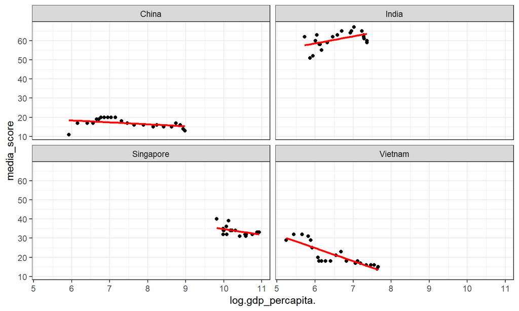

```r
ggplot(d_compare,aes(x=log.gdp_percapita.))+
  geom_point(aes(y=media_score))+
  geom_line(aes(y=.fitted),lwd=1,colour="red")+
  facet_wrap(~country)+
  theme_bw()
```